# 市场观察

2016/11/21

## 一、指数估值

### (一)动态市盈率、市净率

核心指数成分股近18个月的动态市盈率及动态市净率中位数走势如下图所示：

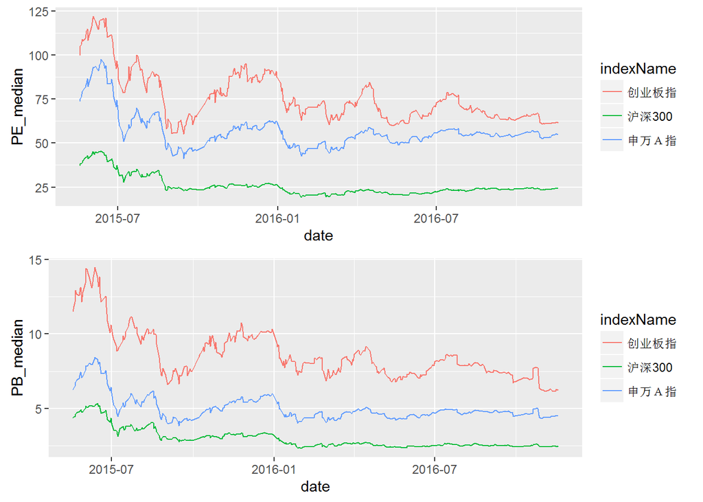

### (二)动态市盈率、市净率百分位

核心指数近18个月的动态市盈率百分位及动态市净率百分位走势如下图所示：

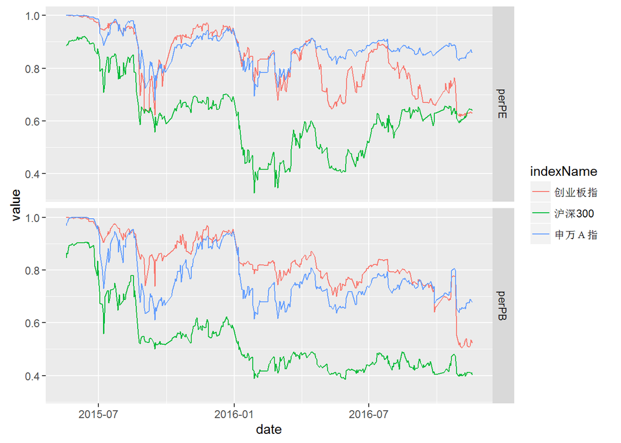

### (三)指数估值概览

纳入观察的18只指数最新的估值情况如下表：

| 日期 | 指数代码 | 指数简称 | 动态市盈率 | 市盈率百分位 | 动态市净率 | 市净率百分位 |
| --- | --- | --- | --- | --- | --- | --- |
| 2016-11-18 | EI000805 | A股资源 | 66.1 | 98.9% | 2.5 | 58.2% |
| 2016-11-18 | EI000979 | 大宗商品 | 54.3 | 97.8% | 2.6 | 48.9% |
| 2016-11-18 | EI801003 | 申万Ａ指 | 54.9 | 86.2% | 4.5 | 67.8% |
| 2016-11-18 | EI000933 | 中证医药 | 44.1 | 85.5% | 4.0 | 7.6% |
| 2016-11-18 | EI000808 | 医药生物 | 45.3 | 84.9% | 4.7 | 27.7% |
| 2016-11-18 | EI399005 | 中小板指P | 44.4 | 76.5% | 4.9 | 50.1% |
| 2016-11-18 | EI399330 | 深证100 | 34.9 | 75.6% | 3.9 | 58.8% |
| 2016-11-18 | EI000819 | 有色金属 | 52.8 | 75.0% | 3.6 | 69.3% |
| 2016-11-18 | EI399959 | 军工指数 | 90.9 | 74.7% | 5.2 | 63.0% |
| 2016-11-18 | EI000934 | 中证金融 | 20.0 | 67.8% | 2.1 | 37.2% |
| 2016-11-18 | EI000300 | 沪深300 | 24.2 | 64.1% | 2.4 | 40.3% |
| 2016-11-18 | EI000905 | 中证500 | 39.6 | 63.3% | 3.3 | 45.2% |
| 2016-11-18 | EI399006 | 创业板指 | 61.4 | 62.9% | 6.2 | 52.3% |
| 2016-11-18 | EI000998 | 中证TMT | 49.0 | 60.5% | 4.6 | 42.2% |
| 2016-11-18 | EI000827 | 中证环保 | 39.7 | 55.5% | 3.2 | 32.8% |
| 2016-11-18 | EI000016 | 上证50 | 16.4 | 49.8% | 1.6 | 15.0% |
| 2016-11-18 | EI801120 | 申万食品饮料 | 38.9 | 47.7% | 4.8 | 68.6% |
| 2016-11-18 | EI000932 | 中证消费 | 30.3 | 33.5% | 4.0 | 31.7% |

## 二、基差

### (一)基差走势

三大股指期货合约基差走势如下图，其中当月合约和次月合约年化基差百分比波动较大，仅展示合约基差百分比，当季合约和次季合约展示基差年化百分比：

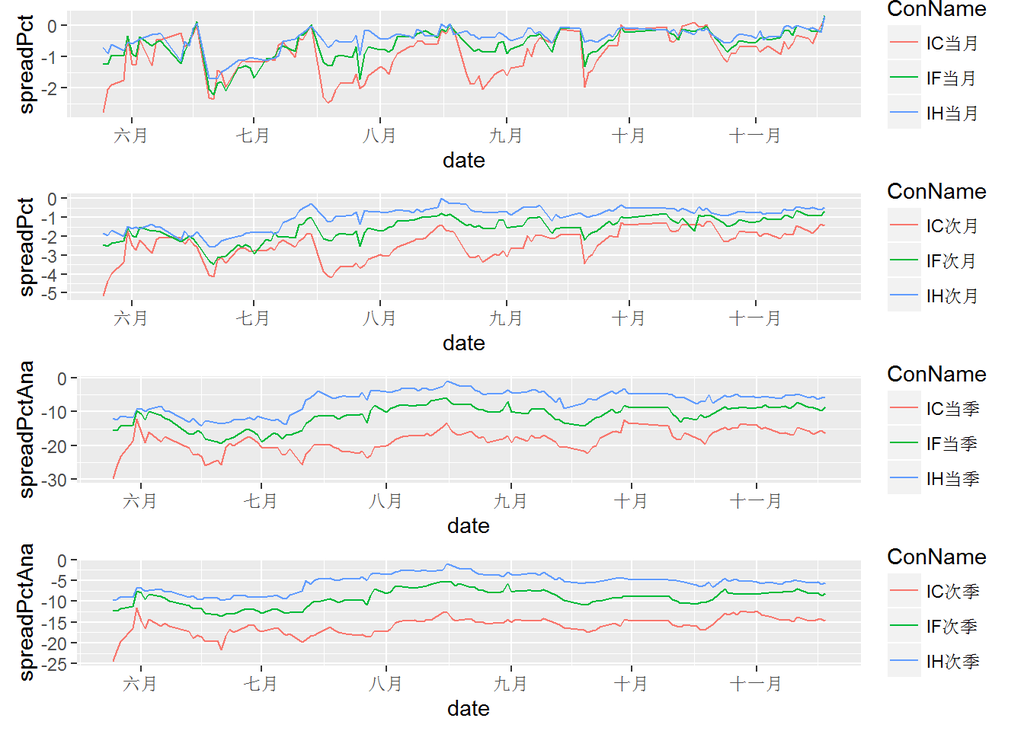

### (二)基差概况

三大股指期货连续合约基差概况如下表，近月合约临近到期日，年化基差百分比数据波动较大：

| 日期 | 合约代码 | 合约收盘价 | 指数收盘价 | 基差 | 基差百分比 | 年化基差百分比 |
| --- | --- | --- | --- | --- | --- | --- |
| 2016-11-18 | IC1611 | 6618.2 | 6602.33 | 15.87 | 0.24% | 0.0% |
| 2016-11-18 | IC1612 | 6506.8 | 6602.33 | -95.53 | -1.45% | -20.6% |
| 2016-11-18 | IC1703 | 6267.8 | 6602.33 | -334.53 | -5.07% | -16.4% |
| 2016-11-18 | IC1706 | 6057.2 | 6602.33 | -545.13 | -8.26% | -14.8% |
| 2016-11-18 | IF1611 | 3427.4 | 3417.46 | 9.94 | 0.29% | 0.0% |
| 2016-11-18 | IF1612 | 3394.6 | 3417.46 | -22.86 | -0.67% | -9.1% |
| 2016-11-18 | IF1703 | 3325.8 | 3417.46 | -91.66 | -2.68% | -8.5% |
| 2016-11-18 | IF1706 | 3260.8 | 3417.46 | -156.66 | -4.58% | -8.1% |
| 2016-11-18 | IH1611 | 2313.8 | 2307.27 | 6.53 | 0.28% | 0.0% |
| 2016-11-18 | IH1612 | 2296.8 | 2307.27 | -10.47 | -0.45% | -6.1% |
| 2016-11-18 | IH1703 | 2265.4 | 2307.27 | -41.87 | -1.81% | -5.7% |
| 2016-11-18 | IH1706 | 2233.6 | 2307.27 | -73.67 | -3.19% | -5.6% |

## 三、套利

### (一)复牌股票套利

近两天复牌股票套利情况如下表：

[1] “无复牌股票套利”

### (二)定增基金跟踪

截止2016-11-21定增基金数据如下表，明细数据参见钱瀚的模板。

| 代码 | 名称 | 到期日期 | 最新净值 | 昨日收盘价 | 折溢价率 | 整体隐含折价率 | 大盘回撤0.1净值回撤 |
| --- | --- | --- | --- | --- | --- | --- | --- |
| 168101.OF | 九泰锐智 | 20200814 | 1.41 | 1.32 | -6.4% | 6.6% | -6.3% |
| 168102.OF | 九泰锐富 | 20210204 | 1.04 | 0.99 | -5.2% | 3.2% | -2.8% |
| 501015.OF | 财通升级 | 20170908 | 1.07 | 1.02 | -5.2% | 10.0% | -5.8% |
| 160518.OF | 博时睿远 | 20171016 | 1.02 | 0.99 | -3.1% | 7.9% | -3.7% |

定增基金近期的净值走势如下图：

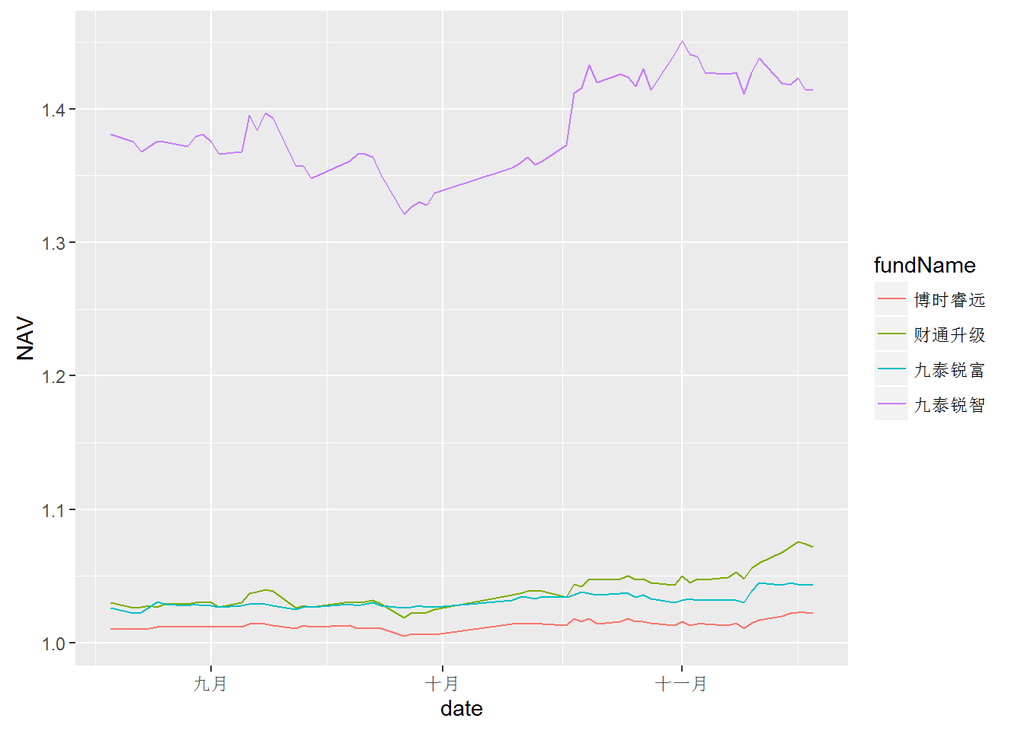

定增基金近期的折溢价率百分比走势如下图：

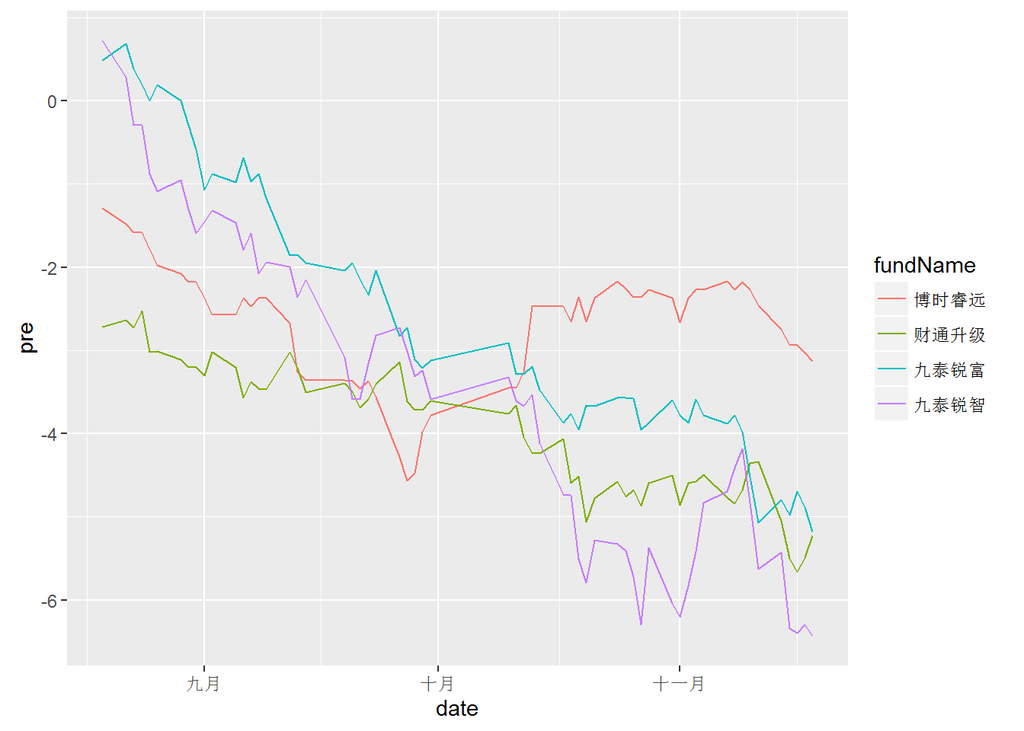

## 四、择时

### (一)大盘均线强弱指数

大盘均线强弱指数在一定程度上可以视为一个反转指标，当大盘均线得分接近8分时，预示市场接近顶部，当大盘均线得分接近0分时，预示市场接近底部。  
大盘均线强弱指数近一年来走势如下图：

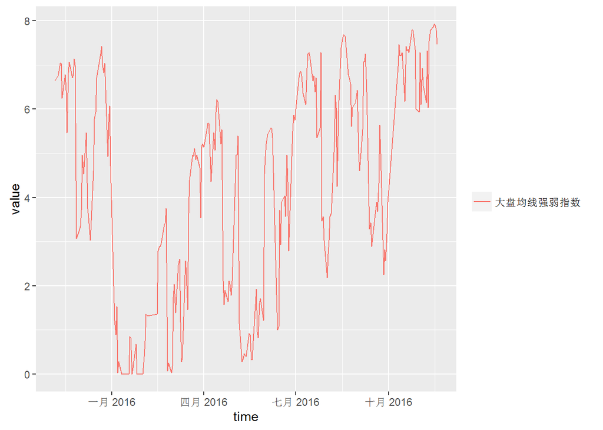

申万一级行业的最新得分见下表：

| 日期 | 指数代码 | 行业 | 最新得分 | 上周得分 |
| --- | --- | --- | --- | --- |
| 2016-11-18 | EI801030 | 化工 | 8 | 8 |
| 2016-11-18 | EI801040 | 钢铁 | 8 | 8 |
| 2016-11-18 | EI801110 | 家用电器 | 8 | 8 |
| 2016-11-18 | EI801130 | 纺织服装 | 8 | 8 |
| 2016-11-18 | EI801150 | 医药生物 | 8 | 8 |
| 2016-11-18 | EI801160 | 公用事业 | 8 | 8 |
| 2016-11-18 | EI801170 | 交通运输 | 8 | 8 |
| 2016-11-18 | EI801180 | 房地产 | 8 | 8 |
| 2016-11-18 | EI801200 | 商业贸易 | 8 | 8 |
| 2016-11-18 | EI801230 | 综合 | 8 | 8 |
| 2016-11-18 | EI801710 | 建筑材料 | 8 | 8 |
| 2016-11-18 | EI801720 | 建筑装饰 | 8 | 8 |
| 2016-11-18 | EI801730 | 电气设备 | 8 | 8 |
| 2016-11-18 | EI801770 | 通信 | 8 | 8 |
| 2016-11-18 | EI801880 | 汽车 | 8 | 8 |
| 2016-11-18 | EI801890 | 机械设备 | 8 | 8 |
| 2016-11-18 | EI801010 | 农林牧渔 | 7 | 8 |
| 2016-11-18 | EI801020 | 采掘 | 7 | 8 |
| 2016-11-18 | EI801050 | 有色金属 | 7 | 8 |
| 2016-11-18 | EI801080 | 电子 | 7 | 8 |
| 2016-11-18 | EI801140 | 轻工制造 | 7 | 8 |
| 2016-11-18 | EI801210 | 休闲服务 | 7 | 8 |
| 2016-11-18 | EI801740 | 国防军工 | 7 | 7 |
| 2016-11-18 | EI801760 | 传媒 | 7 | 7 |
| 2016-11-18 | EI801780 | 银行 | 7 | 8 |
| 2016-11-18 | EI801790 | 非银金融 | 7 | 8 |
| 2016-11-18 | EI801750 | 计算机 | 6 | 8 |
| 2016-11-18 | EI801120 | 食品饮料 | 5 | 6 |

### (二)LLT及均线择时

LLT本质上是一个改进的单均线择时指标，较原始的均线择时延迟更低。  
择时模型和指数本身的净值走势如下图：

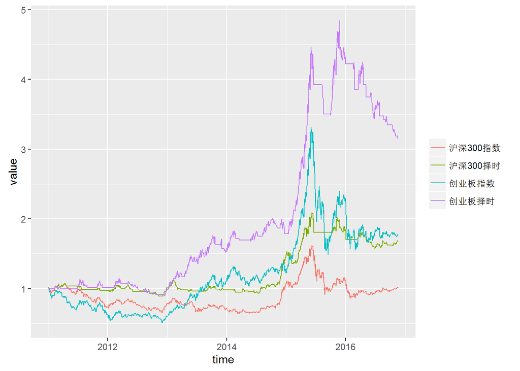

择时模型和指数的收益率统计如下表：

|  | 沪深300指 | 沪深300LLT | 创业板指 | 创业板MA |
| --- | --- | --- | --- | --- |
| 2011-01-04 ~ 2011-12-30 | -25.9% | -2.9% | -37% | 1% |
| 2012-01-04 ~ 2012-12-31 | 6.1% | 4.8% | -3% | -2% |
| 2013-01-04 ~ 2013-12-31 | -8.7% | -3.7% | 81% | 54% |
| 2014-01-02 ~ 2014-12-31 | 49.8% | 51.3% | 11% | 17% |
| 2015-01-05 ~ 2015-12-31 | 4.3% | 23.4% | 82% | 136% |
| 2016-01-04 ~ 2016-11-18 | -9.4% | -8.3% | -21% | -25% |
| 累计收益率 | 1.6% | 67.9% | 77% | 215% |
| 年化收益率 | 0.3% | 9.2% | 10% | 22% |
| 年化波动率 | 24.8% | 15.8% | 34% | 23% |
| 年化Sharpe值 | 1.1% | 58.2% | 30% | 95% |
| 最大回撤 | 47.1% | 24.4% | 55% | 35% |

择时模型最近10个交易日的信号如下表：

| 日期 | 沪深300收盘价 | 沪深300LLT | 沪深300择时信号 | 创业板收盘价 | 创业板MA30 | 创业板择时信号 |
| --- | --- | --- | --- | --- | --- | --- |
| 2016-11-07 | 3356.592 | 3340.798 | hold | 2130.301 | 2171.554 |  |
| 2016-11-08 | 3371.118 | 3343.717 | hold | 2150.302 | 2171.283 |  |
| 2016-11-09 | 3353.055 | 3346.355 | hold | 2123.845 | 2170.007 |  |
| 2016-11-10 | 3390.612 | 3349.473 | hold | 2143.321 | 2169.170 |  |
| 2016-11-11 | 3417.221 | 3354.501 | hold | 2147.107 | 2168.857 |  |
| 2016-11-14 | 3430.248 | 3360.547 | hold | 2161.686 | 2170.149 |  |
| 2016-11-15 | 3429.870 | 3366.681 | hold | 2179.300 | 2171.433 | buy |
| 2016-11-16 | 3429.592 | 3372.467 | hold | 2182.467 | 2172.861 | hold |
| 2016-11-17 | 3436.535 | 3378.158 | hold | 2163.041 | 2173.423 | sell |
| 2016-11-18 | 3417.455 | 3383.147 | hold | 2157.960 | 2173.691 |  |

### (三)网格交易

在经历了三轮股灾，A股逐步回归正常，在过去的一段时间呈现一个震荡的格局，如果未来没有增量信息，很可能维持震荡。结合股指期货的贴水，前期研究了一下网格交易。网格交易的结果如下图：

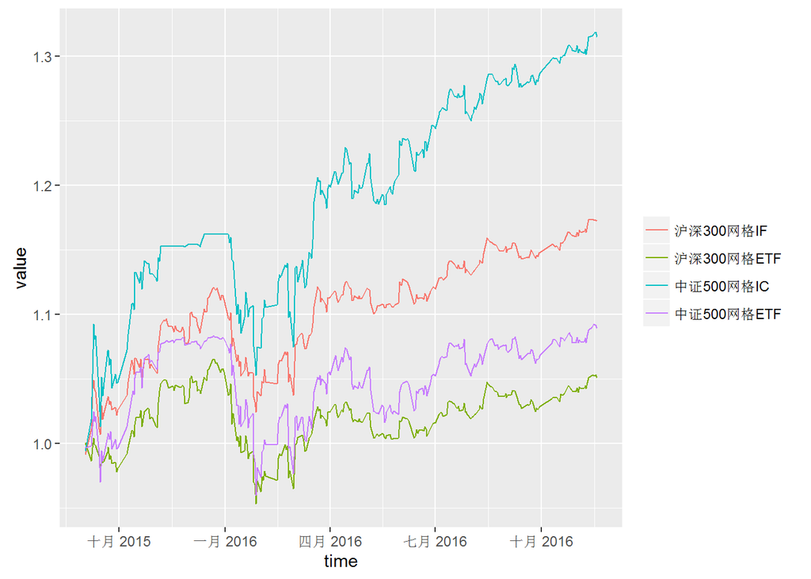

网格交易沪深300股指期货的最新仓位是34%，中证500股指期货的最新仓位是38.1%,网格交易的收益统计如下表：

|  | 沪深300指数 | 沪深300网格IF | 沪深300网格ETF | 中证500指数 | 中证500网格IC | 中证500网格ETF |
| --- | --- | --- | --- | --- | --- | --- |
| 2015-09-02 ~ 2015-12-31 | 11.0% | 11% | 5.6% | 23.5% | 16% | 8.1% |
| 2016-01-04 ~ 2016-11-18 | -8.4% | 5% | -0.4% | -13.3% | 13% | 0.8% |
| 累计收益率 | 1.6% | 17% | 5.1% | 7.0% | 32% | 8.9% |
| 年化收益率 | 1.4% | 14% | 4.2% | 5.7% | 25% | 7.3% |
| 年化波动率 | 24.3% | 10% | 9.9% | 32.8% | 15% | 12.7% |
| 年化Sharpe值 | 5.6% | 137% | 42.1% | 17.5% | 168% | 57.3% |
| 最大回撤 | 26.4% | 9% | 10.5% | 33.5% | 9% | 11.4% |

### (四)银行股轮动

银行股轮动是参考集思录的热门贴银行股评级而来的，数据的提取和参数的设置和原贴有一定的差别，所以轮动的效果也会不太一样，不过回测的效果还不错，从现在开始跟踪。2013年以来银行股轮动的结果如下图：

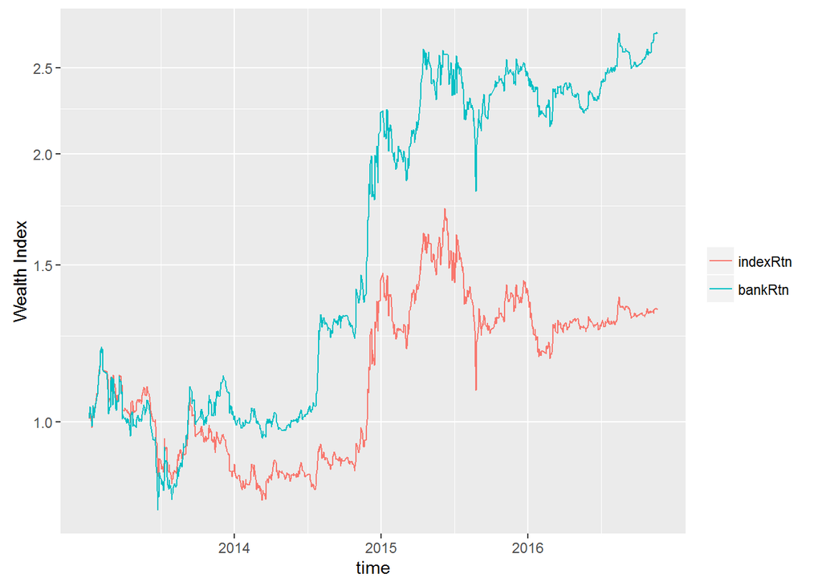

银行股轮动的收益统计如下表：

|  | 申万银行 | 银行股轮动 |
| --- | --- | --- |
| 2013-01-04 ~ 2013-12-31 | -10.3% | 2% |
| 2014-01-02 ~ 2014-12-31 | 61.3% | 119% |
| 2015-01-05 ~ 2015-12-31 | -2.6% | 11% |
| 2016-01-04 ~ 2016-11-18 | -5.1% | 10% |
| 累计收益率 | 33.7% | 173% |
| 年化收益率 | 7.8% | 30% |
| 年化波动率 | 29.3% | 32% |
| 年化Sharpe值 | 26.5% | 92% |
| 最大回撤 | 37.6% | 34% |

银行股轮动的最新得分如下表：

| 日期 | 代码 | 简称 | PB | 预期ROE | 翻倍期 | 持仓 |
| --- | --- | --- | --- | --- | --- | --- |
| 2016-11-18 | EQ601328 | 交通银行 | 0.69 | 0.11 | 2.97 |  |
| 2016-11-18 | EQ601988 | 中国银行 | 0.72 | 0.12 | 3.19 |  |
| 2016-11-18 | EQ601818 | 光大银行 | 0.73 | 0.12 | 3.22 |  |
| 2016-11-18 | EQ600015 | 华夏银行 | 0.79 | 0.15 | 3.28 | hold |
| 2016-11-18 | EQ601288 | 农业银行 | 0.79 | 0.13 | 3.64 |  |
| 2016-11-18 | EQ601398 | 工商银行 | 0.81 | 0.14 | 3.68 |  |
| 2016-11-18 | EQ000001 | 平安银行 | 0.80 | 0.13 | 3.85 |  |
| 2016-11-18 | EQ601939 | 建设银行 | 0.85 | 0.14 | 3.97 |  |
| 2016-11-18 | EQ601166 | 兴业银行 | 0.90 | 0.15 | 4.24 |  |
| 2016-11-18 | EQ600000 | 浦发银行 | 1.00 | 0.15 | 4.90 |  |
| 2016-11-18 | EQ601998 | 中信银行 | 0.90 | 0.12 | 5.31 |  |
| 2016-11-18 | EQ601009 | 南京银行 | 1.03 | 0.14 | 5.42 |  |
| 2016-11-18 | EQ600016 | 民生银行 | 1.03 | 0.14 | 5.53 |  |
| 2016-11-18 | EQ601169 | 北京银行 | 1.04 | 0.14 | 5.73 |  |
| 2016-11-18 | EQ600036 | 招商银行 | 1.15 | 0.15 | 5.93 |  |
| 2016-11-18 | EQ002142 | 宁波银行 | 1.33 | 0.15 | 6.95 |  |